# More Flipping Coins

Consider flipping `size` distinct coins. After each round, each coin that is tails is flipped again. After `n_rounds`, where `n_rounds` is at least one, the proportion of coins that are `heads` is computed. Answer these questions:

1. What is the expected number of heads?
2. What is the standard deviation of the number of heads?

In order to answer these questions, we’ll build a function to help us simulate this scenario.

```r
flip_coins <- function(size = 64, n_rounds = 1) {
  if (n_rounds < 1) stop("n_rounds must be at least 1.")
  x <- sample(c("H", "T"), size = size, replace = TRUE)
  if (n_rounds > 1) {
    for (i in 2:n_rounds) {
      x[x == "T"] <- sample(c("H", "T"), size = sum(x == "T"), replace = TRUE)
    }
  }
  sum(x == "H")
}

flip_coins(n_rounds = 3)
```

```
[1] 59
```

How can we estimate the average number of heads and the standard deviation associated with number of heads? We can certainly use probability theory. An alternative approach is a Monte Carlo or simulation study.

```r
n_reps <- 1000
n_rounds <- 3
```

#### For Loop

```r
library(tictoc)

n_heads <- numeric(n_reps)
tic("For Loop")
for (i in seq_along(n_heads)) {
  n_heads[i] <- flip_coins(n_rounds = n_rounds)
}
toc()
```

```
For Loop: 0.055 sec elapsed
```

#### sapply / replicate

```r
tic("sapply")
n_heads <- sapply(1:n_reps, function(x) flip_coins(n_rounds = n_rounds))
toc()
```

```
sapply: 0.06 sec elapsed
```

```r
tic("replicate")
n_heads <- replicate(n_reps, flip_coins(n_rounds = n_rounds))
toc()
```

```
replicate: 0.055 sec elapsed
```

#### Tidyverse

```r
library(tidyverse)
tic("purrr")
n_heads <- rerun(n_reps, flip_coins(n_rounds = n_rounds)) %>%
  unlist()
toc()
```

```
purrr: 0.062 sec elapsed
```

Now that we have the sampling distribution of the number of heads (`n_heads`), we can summarise it.

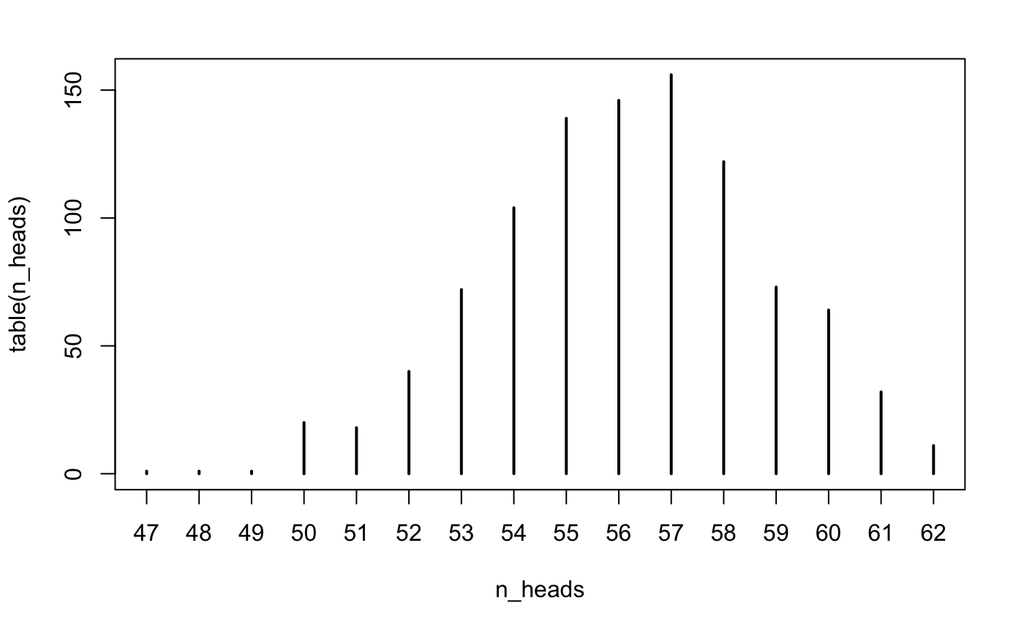

```r
plot(table(n_heads))
```

```r
table(n_heads) / length(n_heads)
```

```
n_heads
   47    48    49    50    51    52    53    54    55    56    57    58    59    60    61    62
0.001 0.001 0.001 0.020 0.018 0.040 0.072 0.104 0.139 0.146 0.156 0.122 0.073 0.064 0.032 0.011
```

```r
mean(n_heads)
```

```
[1] 56.144
```

```r
sd(n_heads)
```

```
[1] 2.591134
```

Is there uncertainty in these summaries? Yes! So, how do we understand and communicate those uncertainties? Well, we could just wrap our simulation inside another simulation!

[figure not shown]

Now we’re going to produce 1000 Monte Carlo estimates of the mean and standard deviation.

```r
mc_estimates <- replicate(1000, {
  n_heads <- replicate(n_reps, flip_coins(n_rounds = 3))
  c(mean(n_heads), sd(n_heads))
})
dim(mc_estimates)
```

```
[1]    2 1000
```

```r
mc_means <- mc_estimates[1,]
mc_sds <- mc_estimates[2,]
```

Now we can look at the distribution of our simulation estimates.

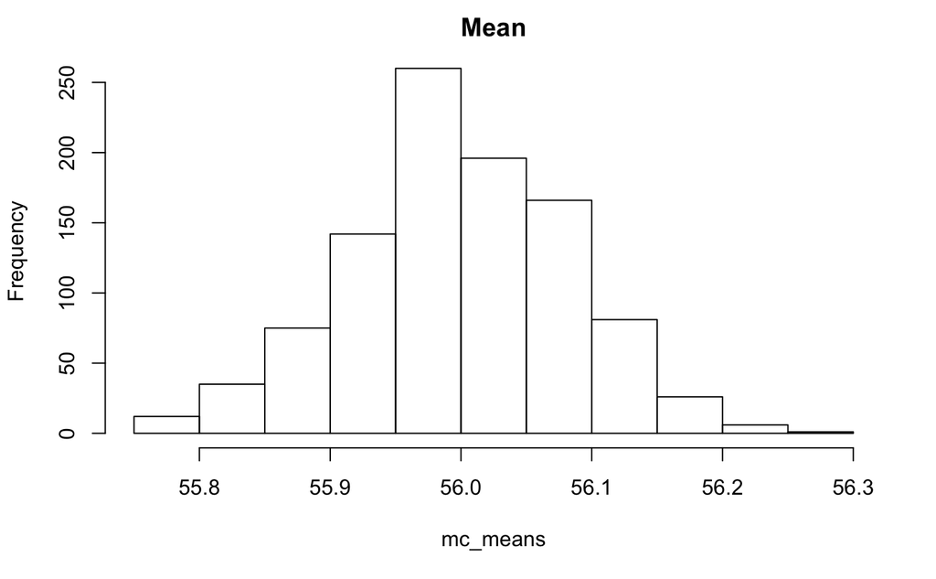

```r
hist(mc_means, main = "Mean")
```

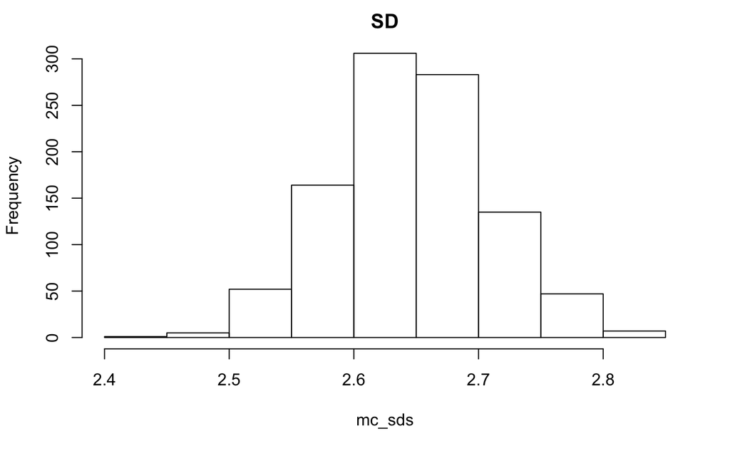

```r
hist(mc_sds, main = "SD")
```

Now we can compute a 95% confidence interval for these estimates.

```r
quantile(mc_means, c(0.025, 0.975))
```

```
    2.5%    97.5%
55.82297 56.16207
```

```r
quantile(mc_sds, c(0.025, 0.975))
```

```
    2.5%    97.5%
2.523621 2.770260
```

That worked!! But, it was exceptionally computationally intensive (1000 * 1000 simulations). Is there a better way to assess this uncertainty without going through all of this? Yes! We can invoke the Central Limit Theorem. Since `n_reps` is large, the CLT applies. When our sample size grows large, the distribution of our sample means is approximately normally distributed with $\mu_{\bar{x}} = \mu$ and $\sigma_{\bar{x}} = \sigma / \sqrt{n}$.

```r
simulation_ci <- function(x, confidence_level = 0.95) {
  n <- length(x)
  m <- mean(x)
  s <- sd(x)
  area <- 1 - (1 - confidence_level)/2
  m + c(-1, 1) * qnorm(area) * s / sqrt(n)
}
```

The function above simply calculates a confidence interval by implementing:
$$C.I. = \bar{x}\pm z_{\alpha/2} \frac{\sigma}{\sqrt{n}}$$

Where $\bar{x}$ is the sample mean and $s$ is the sample standard deviation, and $z_{\alpha/2}$ is the Z score for the desired confidence level $\alpha$. This Z score can be calculated using `qnorm()`.

```r
simulation_ci(n_heads)
```

```
[1] 55.9834 56.3046
```

Note that we can also extend this same formula to provide a confidence interval estimate for the standard deviation of `n_heads`. Given that the standard deviation is defined as $\sqrt{\frac{1}{N}\sum_{i=1}^N(x_i - \mu)^2}$ then we can do the following:

```r
sqrt(simulation_ci((n_heads - mean(n_heads))^2))
```

```
[1] 2.478616 2.696478
```

Now we have a way of assessing the simulation error without running an incredible amount of simulations, and it’s all thanks to the Central Limit Theorem.